# HOMEWORK1- PCA with LOGISTIC REGRESSION

Mamady III DIAKITE

2023-12-1

# PART1

### A.Read the data-set as a data frame.

```r
myDataFrame <- read.csv("data.csv")
```

### B.Check data types using the str function:

```r
str(myDataFrame)
```

```
## 'data.frame':    569 obs. of  33 variables:
##  $ id                     : int  842302 842517 84300903 84348301 84358402 843786 844359 84458202 844981 84501001 ...
##  $ diagnosis              : chr  "M" "M" "M" "M" ...
##  $ radius_mean            : num  18 20.6 19.7 11.4 20.3 ...
##  $ texture_mean           : num  10.4 17.8 21.2 20.4 14.3 ...
##  $ perimeter_mean         : num  122.8 132.9 130 77.6 135.1 ...
##  $ area_mean              : num  1001 1326 1203 386 1297 ...
##  $ smoothness_mean        : num  0.1184 0.0847 0.1096 0.1425 0.1003 ...
##  $ compactness_mean       : num  0.2776 0.0786 0.1599 0.2839 0.1328 ...
##  $ concavity_mean         : num  0.3001 0.0869 0.1974 0.2414 0.198 ...
##  $ concave.points_mean    : num  0.1471 0.0702 0.1279 0.1052 0.1043 ...
##  $ symmetry_mean          : num  0.242 0.181 0.207 0.26 0.181 ...
##  $ fractal_dimension_mean : num  0.0787 0.0567 0.06 0.0974 0.0588 ...
##  $ radius_se              : num  1.095 0.543 0.746 0.496 0.757 ...
##  $ texture_se             : num  0.905 0.734 0.787 1.156 0.781 ...
```

[output cut: 19 more lines]

### C.Check for any missing values

```r
myData <- myDataFrame[, 1:32]  # Extracting columns 1 to 32
sum(is.na(myData))  # Count total missing values
```

```
## [1] 0
```

```r
sapply(myData, function(x) sum(is.na(x)))  # Count missing values for each column
```

```
##                      id               diagnosis             radius_mean
##                       0                       0                       0
##            texture_mean          perimeter_mean               area_mean
##                       0                       0                       0
##         smoothness_mean        compactness_mean          concavity_mean
##                       0                       0                       0
##     concave.points_mean           symmetry_mean  fractal_dimension_mean
##                       0                       0                       0
##               radius_se              texture_se            perimeter_se
##                       0                       0                       0
##                 area_se           smoothness_se          compactness_se
##                       0                       0                       0
##            concavity_se       concave.points_se             symmetry_se
##                       0                       0                       0
##    fractal_dimension_se            radius_worst           texture_worst
##                       0                       0                       0
##         perimeter_worst              area_worst        smoothness_worst
##                       0                       0                       0
##       compactness_worst         concavity_worst    concave.points_worst
##                       0                       0                       0
##          symmetry_worst fractal_dimension_worst
##                       0                       0
```

### D. Correlation using corrplot:

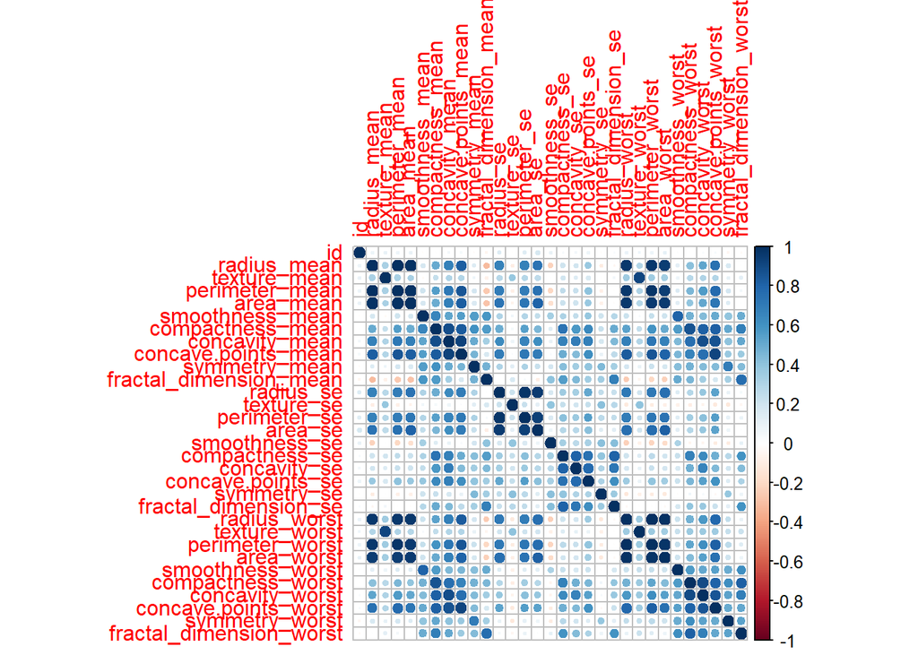

```r
library(corrplot)
numeric_data <- myData[, sapply(myDataFrame, is.numeric)]  # Select numeric columns

correlation_matrix <- cor(numeric_data)  # Calculate correlation matrix

corrplot(correlation_matrix, method = "circle")  # Plot correlation matrix
```

# PART 2

### A. Split data into train and test:

```r
library(caTools)
myData$diagnosis <- factor(myData$diagnosis)  # Convert diagnosis to a factor
set.seed(123)
ind <- sample(2, nrow(myData), replace = TRUE, prob = c(0.7, 0.3))  # Split into train (70%) and test (30%)
train <- myData[ind == 1,]  # Select train data
test <- myData[ind == 2,]   # Select test data
```

### B. Build logistic model:

```r
fit <- glm(diagnosis ~ . , family=binomial, train)
summary(fit)
```

```
##
## Call:
## glm(formula = diagnosis ~ ., family = binomial, data = train)
##
## Coefficients:
##                           Estimate Std. Error z value Pr(>|z|)
## (Intercept)             -1.313e+03  5.065e+05  -0.003    0.998
## id                       3.843e-08  2.403e-04   0.000    1.000
## radius_mean             -4.388e+02  2.244e+05  -0.002    0.998
## texture_mean             2.742e+01  6.831e+03   0.004    0.997
## perimeter_mean           3.382e+01  2.919e+04   0.001    0.999
## area_mean                1.537e+00  1.065e+03   0.001    0.999
## smoothness_mean          9.323e+03  2.642e+06   0.004    0.997
## compactness_mean        -5.656e+03  1.915e+06  -0.003    0.998
## concavity_mean           4.433e+03  1.257e+06   0.004    0.997
## concave.points_mean     -3.714e+03  2.320e+06  -0.002    0.999
## symmetry_mean           -1.558e+03  7.490e+05  -0.002    0.998
## fractal_dimension_mean  -8.239e+02  3.603e+06   0.000    1.000
## radius_se               -3.739e+02  5.515e+05  -0.001    0.999
## texture_se               1.106e+02  4.298e+04   0.003    0.998
## perimeter_se             1.794e+01  1.606e+04   0.001    0.999
## area_se                  9.962e-01  6.194e+03   0.000    1.000
## smoothness_se           -2.392e+04  1.351e+07  -0.002    0.999
## compactness_se           7.034e+03  2.604e+06   0.003    0.998
## concavity_se             3.159e+02  1.627e+06   0.000    1.000
## concave.points_se        2.582e+04  5.247e+06   0.005    0.996
## symmetry_se             -1.975e+03  2.973e+06  -0.001    0.999
## fractal_dimension_se    -9.436e+04  2.286e+07  -0.004    0.997
## radius_worst             2.788e+02  7.698e+04   0.004    0.997
## texture_worst           -1.234e+01  6.605e+03  -0.002    0.999
## perimeter_worst         -2.035e+01  6.056e+03  -0.003    0.997
## area_worst              -3.495e-01  6.654e+02  -0.001    1.000
## smoothness_worst        -1.045e+02  1.507e+06   0.000    1.000
## compactness_worst       -1.665e+02  4.326e+05   0.000    1.000
## concavity_worst         -8.086e+02  2.503e+05  -0.003    0.997
## concave.points_worst     1.581e+03  8.012e+05   0.002    0.998
## symmetry_worst           9.033e+02  6.609e+05   0.001    0.999
## fractal_dimension_worst  9.461e+03  2.051e+06   0.005    0.996
##
## (Dispersion parameter for binomial family taken to be 1)
##
##     Null deviance: 5.2474e+02  on 404  degrees of freedom
## Residual deviance: 2.9767e-07  on 373  degrees of freedom
## AIC: 64
##
## Number of Fisher Scoring iterations: 25
```

### C. Discuss about the summary of your model.

In this output, the p-values for most variables are high (close to 1), indicating that these predictors are not statistically significant. This might suggest that the model is overfitting or that some variables do not contribute significantly to predicting the response. The residual deviance is very close to zero, indicating a good fit of the model to the data. The AIC value of 64 is a measure of the model fit. Lower AIC values are generally better, but the interpretation depends on the context and the comparison with other models.

### D. Use predict function and then get the confusion matrix:

```r
predictions <- predict(fit, newdata = test, type = "response")  # Make predictions
threshold <- 0.5  # Set threshold for classifying predictions
predicted_classes <- ifelse(predictions > threshold, 1, 0)  # Classify predictions

test$diagnosis <- ifelse(test$diagnosis == "M", 1, 0)  # Convert test diagnosis to binary
```

Confusion matrix

```r
library(caret)
conf_matrix2 <- confusionMatrix(data = factor(predicted_classes), reference = factor(test$diagnosis), positive = "1")
conf_matrix2
```

```
## Confusion Matrix and Statistics
##
##           Reference
## Prediction  0  1
##          0 80  6
##          1 14 64
##
##                Accuracy : 0.878
##                  95% CI : (0.818, 0.9239)
##     No Information Rate : 0.5732
##     P-Value [Acc > NIR] : <2e-16
##
##                   Kappa : 0.7543
##
##  Mcnemar's Test P-Value : 0.1175
##
##             Sensitivity : 0.9143
##             Specificity : 0.8511
##          Pos Pred Value : 0.8205
##          Neg Pred Value : 0.9302
##              Prevalence : 0.4268
##          Detection Rate : 0.3902
##    Detection Prevalence : 0.4756
##       Balanced Accuracy : 0.8827
##
##        'Positive' Class : 1
##
```

### E. Discuss performance measures:

Performance Metrics: Accuracy: 0.878

Logistic Regression achieved an overall accuracy of 87.8%. Sensitivity (True Positive Rate): 0.9143

The model correctly identified 91.43% of actual positive cases. Specificity (True Negative Rate): 0.8511

Logistic Regression correctly identified 85.11% of actual negative cases. Positive Predictive Value (Precision): 0.8205

82.05% of predicted positives are true positives in Logistic Regression. Negative Predictive Value: 0.9302

93.02% of predicted negatives are true negatives in Logistic Regression.

# PART 3:

### A. Apply PCA and choose your PC’s:

```r
features <- myData[, 3:ncol(myData)]  # Select features
scaled_features <- scale(features)  # Standardize features
pca_result <- prcomp(scaled_features)  # Apply PCA
summary(pca_result)
```

```
## Importance of components:
##                           PC1    PC2     PC3     PC4     PC5     PC6     PC7
## Standard deviation     3.6444 2.3857 1.67867 1.40735 1.28403 1.09880 0.82172
## Proportion of Variance 0.4427 0.1897 0.09393 0.06602 0.05496 0.04025 0.02251
## Cumulative Proportion  0.4427 0.6324 0.72636 0.79239 0.84734 0.88759 0.91010
##                            PC8    PC9    PC10   PC11    PC12    PC13    PC14
## Standard deviation     0.69037 0.6457 0.59219 0.5421 0.51104 0.49128 0.39624
## Proportion of Variance 0.01589 0.0139 0.01169 0.0098 0.00871 0.00805 0.00523
## Cumulative Proportion  0.92598 0.9399 0.95157 0.9614 0.97007 0.97812 0.98335
##                           PC15    PC16    PC17    PC18    PC19    PC20   PC21
## Standard deviation     0.30681 0.28260 0.24372 0.22939 0.22244 0.17652 0.1731
## Proportion of Variance 0.00314 0.00266 0.00198 0.00175 0.00165 0.00104 0.0010
## Cumulative Proportion  0.98649 0.98915 0.99113 0.99288 0.99453 0.99557 0.9966
##                           PC22    PC23   PC24    PC25    PC26    PC27    PC28
## Standard deviation     0.16565 0.15602 0.1344 0.12442 0.09043 0.08307 0.03987
## Proportion of Variance 0.00091 0.00081 0.0006 0.00052 0.00027 0.00023 0.00005
## Cumulative Proportion  0.99749 0.99830 0.9989 0.99942 0.99969 0.99992 0.99997
##                           PC29    PC30
## Standard deviation     0.02736 0.01153
## Proportion of Variance 0.00002 0.00000
## Cumulative Proportion  1.00000 1.00000
```

### B. Use logistic regression with your PCs:

```r
chosen_components <- 2  # Number of principal components
pc_data <- as.data.frame(pca_result$x[, 1:chosen_components])  # Select principal components
pc_data$diagnosis <- myData$diagnosis  # Add diagnosis column
```

```r
model_pca <- glm(diagnosis ~ ., data = pc_data, family = "binomial")  # Build logistic model with PCA
summary(model_pca)  # Display summary of the PCA model
```

```
##
## Call:
## glm(formula = diagnosis ~ ., family = "binomial", data = pc_data)
##
## Coefficients:
##             Estimate Std. Error z value Pr(>|z|)
## (Intercept)  -0.4261     0.2205  -1.933   0.0533 .
## PC1          -2.1969     0.2686  -8.179 2.86e-16 ***
## PC2           1.2255     0.1802   6.800 1.04e-11 ***
## ---
## Signif. codes:  0 '***' 0.001 '**' 0.01 '*' 0.05 '.' 0.1 ' ' 1
##
## (Dispersion parameter for binomial family taken to be 1)
##
##     Null deviance: 751.44  on 568  degrees of freedom
## Residual deviance: 137.58  on 566  degrees of freedom
## AIC: 143.58
##
## Number of Fisher Scoring iterations: 8
```

### D. Use predict function and then get the confusion matrix:

```r
# Applying PCA to the test data
scaled_test_data <- scale(test[, 3:ncol(test)])  # Standardize test data
pc_test_data <- predict(pca_result, newdata = scaled_test_data)[, 1:chosen_components]  # Apply PCA to test data
class(pc_test_data)
```

```
## [1] "matrix" "array"
```

```r
pc_test_data <- as.data.frame(pc_test_data)  # Convert to data frame
class(pc_test_data)
```

```
## [1] "data.frame"
```

```r
# Predict using the logistic model with PCs
predictions_pca <- predict(model_pca, newdata = pc_test_data, type = "response")  # Make predictions with PCA
predicted_classes_pca <- ifelse(predictions_pca > threshold, 1, 0)  # Classify predictions
```

```r
# Confusion matrix
conf_matrix_pca <- confusionMatrix(data = factor(predicted_classes_pca), reference = factor(test$diagnosis), positive = "1")
conf_matrix_pca
```

```
## Confusion Matrix and Statistics
##
##           Reference
## Prediction  0  1
##          0 55 14
##          1 39 56
##
##                Accuracy : 0.6768
##                  95% CI : (0.5995, 0.7477)
##     No Information Rate : 0.5732
##     P-Value [Acc > NIR] : 0.0041927
##
##                   Kappa : 0.3683
##
##  Mcnemar's Test P-Value : 0.0009784
##
##             Sensitivity : 0.8000
##             Specificity : 0.5851
##          Pos Pred Value : 0.5895
##          Neg Pred Value : 0.7971
##              Prevalence : 0.4268
##          Detection Rate : 0.3415
##    Detection Prevalence : 0.5793
##       Balanced Accuracy : 0.6926
##
##        'Positive' Class : 1
##
```

### E. Discuss about the performance measures.

Similar to Part 2.E, metrics are discussed based on the confusion matrix of the PCA model. This represents the overall correctness of predictions. In PCA, 67.68% of the predictions are correct. Sensitivity (True Positive Rate): 0.8000 Sensitivity measures the ability of the model to correctly identify positive instances (class 1). Here, 80% of actual positive cases were correctly identified by the PCA model. Specificity (True Negative Rate): 0.5851

## F. Compare results 2.E and 3.E:

Compare performance metrics of Logistic Regression and PCA models. Logistic Regression outperforms PCA in various metrics, indicating better predictive performance for the given dataset. Logistic Regression has a higher ability to correctly identify negative cases. Positive Predictive Value: Logistic Regression (0.8205) > PCA (0.5895)

Logistic Regression has a higher precision in predicting positive cases. Negative Predictive Value: Logistic Regression (0.9302) > PCA (0.7971)

Logistic Regression has a higher accuracy in predicting negative cases. In summary, Logistic Regression outperforms PCA in various metrics, indicating better predictive performance for the given dataset. These metrics provide insights into how well each model is performing with respect to correctly classifying instances of each class.